```r
create_chart_fn <- function(rdistr, distr, discreet=F, n=1000, ...) {
  set.seed(123)
  x = rdistr(n, ...)

  if(!discreet) {
    hist(
      x,
      probability = T,
      col = "lightblue",
      border = "white",
      xlab = "x"
    )
    curve(
      distr(x, ...),
      from = min(x),
      to = max(x),
      add = T,
      col = "red",
      lwd = 2
    )
  } else {
    tab = table(x) / length(x)

    bar_centers = barplot(
      tab,
      col = "lightblue",
      border = "white",
      ylab = "Probabilità"
    )

    points(
      bar_centers,
      #as.numeric(names(tab)),
      distr(as.numeric(names(tab)), ...),
      col = "red",
      pch = 19
    )
  }
}
```

# Distribuzioni

## Distribuzioni discrete

### Bernoulli

**Definizione:**

Esperimento con solo 2 esiti possibili

[output not shown]

**Legge**:

$$X € \{0,1\}, P(X = x) = p^x(1-p)^{1-x}$$

- **Media**: E[X] = p
- **Varianza**: Var[X] = p(1-p)

**Stimatori**:

- media: $\hat{p} = \bar{X} = \frac{1}{n}\sum_{i=1}^{n}X_i$
- varianza: $S^2 = \bar{X}(1-\bar{X}) = \hat{p}(1-\hat{p})$

**Esempio:**

- Probabilità che lanciando una moneta esca testa piuttosto che croce
- Probabilità che una persona abbia una specifica malattia

**In R:**

Non esiste una bernoulliana in R

**Relazioni:**

- Somma di n Bernoulli(p) -> Binomiale(n, p)

### Binomiale

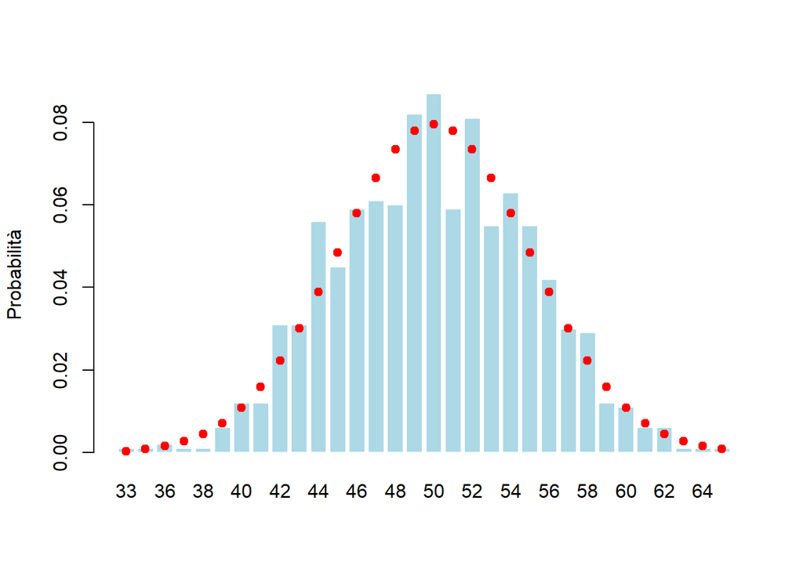

```r
create_chart_fn(rbinom,dbinom, discreet=T, size=100, prob=0.5 )
```

**Definizione:**

Conta il numero di successi in n prove Bernoulliane indipendenti

**Legge:**

$$p(X = k) = \binom{n}{k} * p^k(1-p)^{n-k}$$

- **Media**: E(X) = n*p
- **Varianza**: Var(X) = np(1-p)

**Stimatori:**

- media: $\hat{p} = \frac{\bar{X}}{n}$
- varianza: $S^2 = \frac{\bar{X}}{n}(1- \frac{\bar{X}}{n})n = \hat{p}(1-\hat{p})n$

**Esempio:**

- Numero di prodotti difettosi in un lotto di n pezzi
- Numero di persone con una malattia in una determinata popolazione

**Relazioni:**

- da approfondire relazione con poisson

### Geometrica

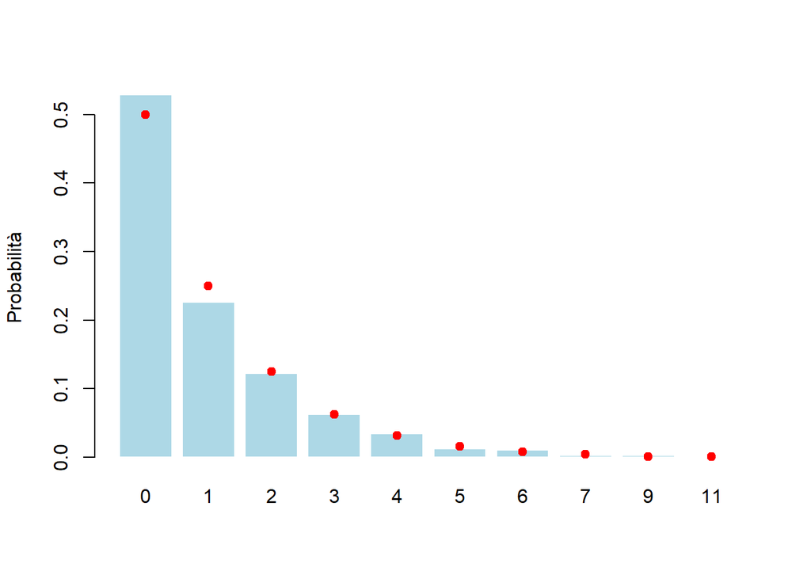

```r
create_chart_fn(rgeom, dgeom, discreet=T, prob=0.5 )
```

**Definizione:**

**Legge**:

- **Media**: E(X) = 1/p
- **Varianza**: Var(X) = $(1-p)/p^2$

**Stimatori**:

- **Media**: $\hat{p} = 1/\bar{X}$
- **Varianza**: S^2 = $\frac{\bar{X}-1}{\bar{X}^2}$

**Esempio**:

Numero di tiri di dado fino ad ottenere il primo 6

**Relazioni:**

Somma di r geometriche -> negativo binomiale

### Poisson

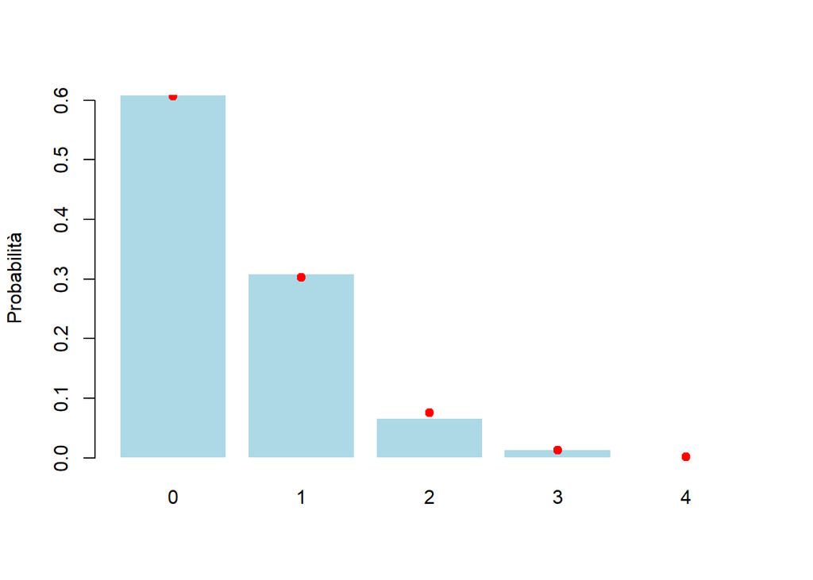

```r
create_chart_fn(rpois, dpois, discreet=T, lambda=0.5 )
```

**Definizione:**

Numero di eventi indipendenti in intervallo con media $\lambda$

**Legge:**

$$P(X = k) = e^{-\lambda}*\frac{\lambda^k}{k!}, k = 0,1,2,...$$

- **Media** = E(X) = **varianza** = Var(X) = $\lambda$

**Stimatori**:

$media=\hat{\lambda}=varianza=S^2=\bar{X}$

**Esempio:**

Numero di e-mail ricevute in un ora

**Relazioni:**

Limite della binomiale per n $\to \infty$

## Distribuzioni continue

### Uniforme continua

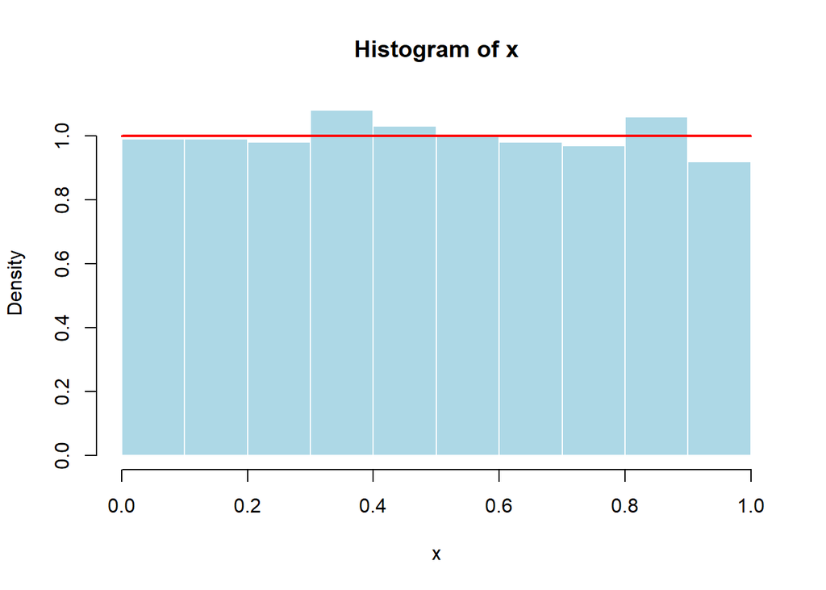

```r
create_chart_fn(runif,dunif, min=0, max=1)
```

**Definizione:**

Ogni valore tra a e b con la stessa possibilità

**Legge:**

- Media: E(X) = (a+b)/2
- Varianza: Var(X) = $(b-a)^2/12$

Stimatori:

**Esempio:**

Numero casuale tra 0 e 1

**Relazione:**

Base per la generazione di distribuzioni con trasformazioni invrse

### Esponenziale

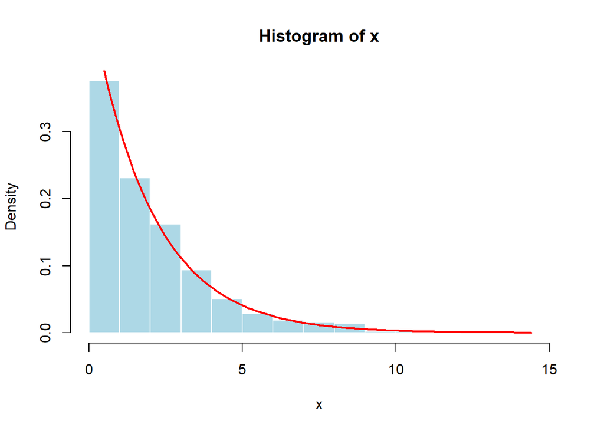

```r
create_chart_fn(rexp,dexp, rate=0.5)
```

**Definizione**:

Tempo di attesa tra 2 eventi di poisson consecutivi

$$f(x) = \lambda*e^{-\lambda x}, x \ge 0$$

**media**: $1/\lambda$

**varianza**: $1/\lambda^2$

**Stimatori:**

- $\hat{\lambda} = 1/\bar{X}$
- $\sigma^2 = \bar{X}^2$

**Esempio:**

Tempo fino al prossimo arrivo o guasto

**Relazioni:**

- Somma di k esponenziali -> Gamma(k, $\lambda$)

### Normale

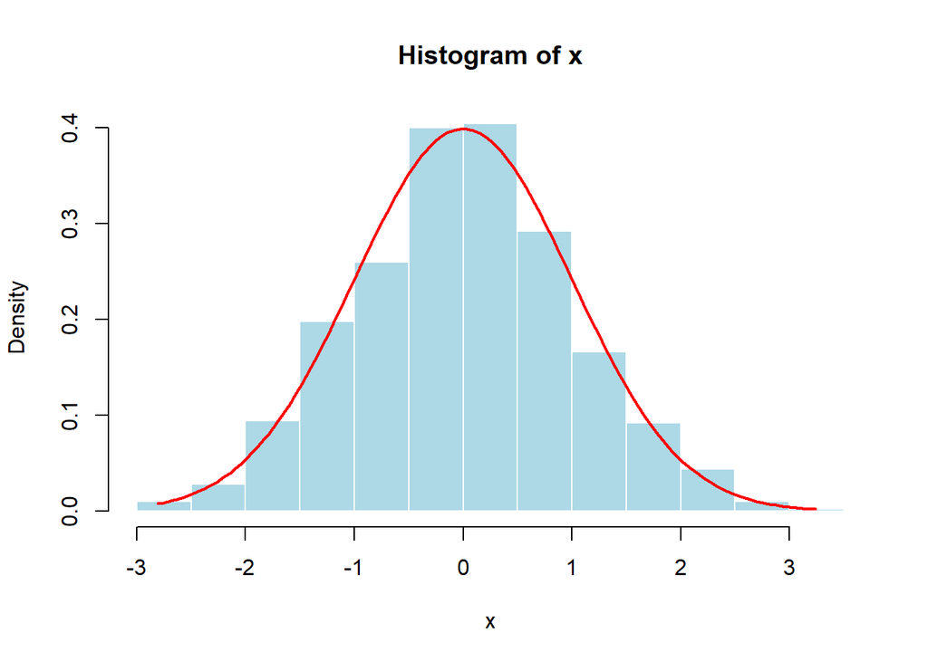

```r
create_chart_fn(rnorm, dnorm, mean=0, sd=1)
```

Variabile continua con densità simmetrica e a campana

$$f(x) = \frac{e^{-\frac{(x-\mu)^2}{2\sigma^2}}}{\sigma\sqrt{2\pi}}$$

- **Media**: $\mu$
- **Varianza**: $\sigma^2$

**Stimatori**:

- $\hat{\mu} = \bar{X}$
- $\sigma^2 = 1/n\sum_{i=1}^n(X_i - \bar{X)^2}$
- $s^2 = \frac{\sum_{i=1}^n(X_i - \bar{X)^2}}{n-1}$

**Distribuzioni derivate:**

- $\hat{X} \sim N(\mu,\sigma^2/n)$
- $\frac{n-1S^2}{\sigma^2}\sim\chi^2_{n-1}$
- $\frac{\bar{X}-\mu}{s/\sqrt{n}}\sim t_{n-1}$

**Esempio:**

- Errori sperimentali
- Distribuzione altezze in una popolazione
- Distribuzione di medie campionarie

### Gamma

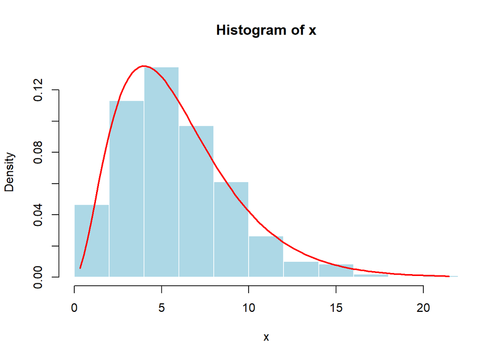

```r
create_chart_fn(rgamma, dgamma, shape=3, scale=2)
```

Definizione:

Somma di variabili esponenziali indipendenti

Legge:

$$f(x) = \frac{x^{\alpha-1}*e^{-x/\beta}}{\Gamma(\alpha)\beta^\alpha}$$

### Chi-quadro

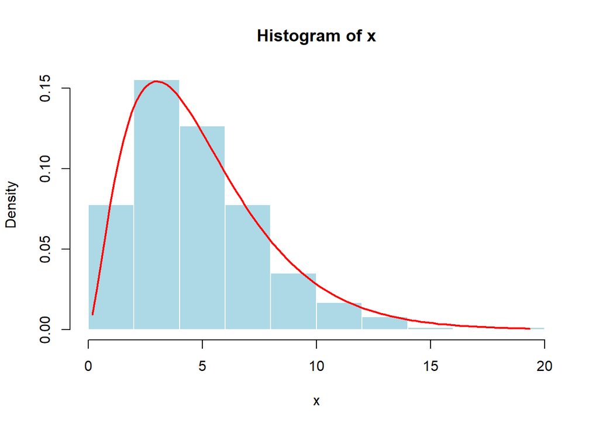

```r
create_chart_fn(rchisq, dchisq, df=5)
```

```r
#df -> gradi di libertà
```

**Definizione:**

Somma dei quadrati di k variabili N(0,1)

$$f(x)=\frac{x^{k/2-1}e^{-x/2}}{2^{k/2}\Gamma(k/2)}, x>0$$

**media**: k

**varianza**: 2k

**stimatori:**

- Se $X_i \sim N(\mu, \sigma^2) \to \hat\sigma^2 = S^2$

**Esempio:**

- Test di bontà dell’adattamento
- Test sulle varianze

Relazioni:

- Caso particolare di gamma(k/2, 2)
- Base per t e F

### T di student

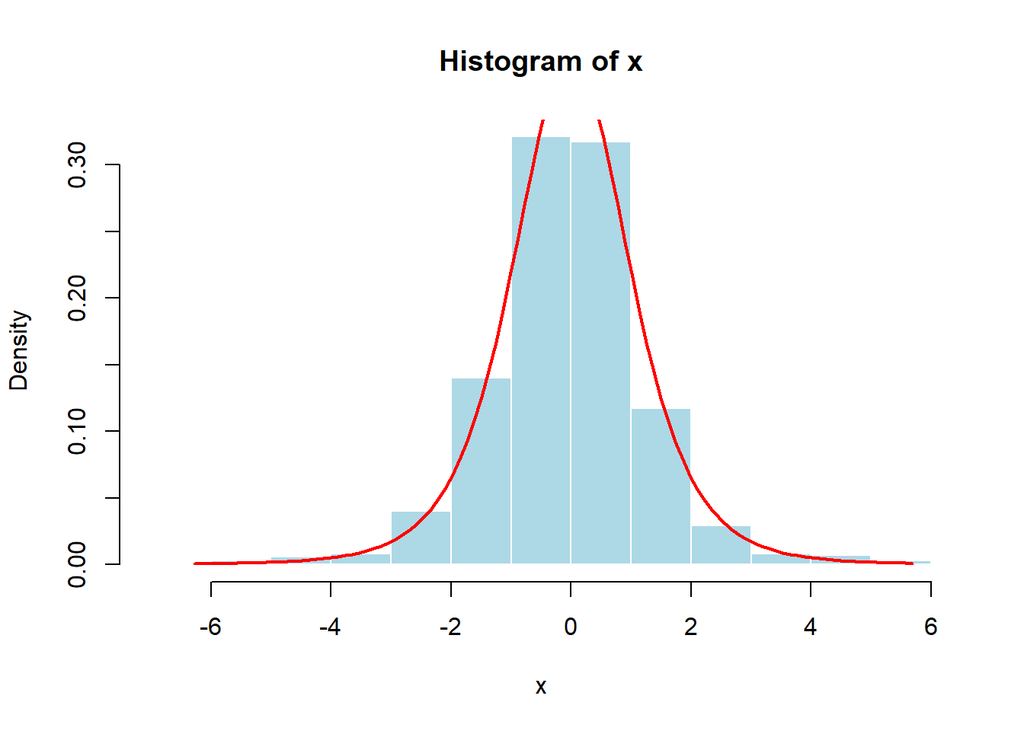

```r
create_chart_fn(rt, dt, df=5)
```

Definizione:

Rapporto tra una normale standard e la radice quadrata di una chi quadro normalizzata

Legge:

$$T = \frac{Z}{\sqrt{U/v}}, Z \sim N(0,1), U \sim \chi^2(v)$$

Media: 0

Varianza: $\frac{v}{v-2}, v > 2$

Stimatori:

- se $X_i \sim N(\mu, \sigma^2)$ => $\frac{\bar{X}-\mu}{S/\sqrt{n}} \sim t_{n-1}$ -> usata per stimare intervalli di confidenza con $\sigma^2$ ignota

**Esempio**:

Analisi inferenziale per piccole dimensioni campionarie

**Relazioni**:

Per $v\to \infty \to$ Normale standard

### F di Fisher

```r
# create_chart_fn(rf, df, df1=5, df2=10)
```

**Definizione**:

Rapporto tra due variabili chi-quadro normalizzate.

**Legge**:

$$F = \frac{U_1/d_1}{U_2/d_2}, U_1 \sim \chi^2(d_1), U_2 \sim \chi^2(d_2)$$

- **Media**: $\frac{d_2}{d_2-2}, d2 > 2$

**Stimatori collegati**:

- Confronto di due varianze campionarie $F = \frac{S_1^2/\sigma_1^2}{S_2^2/\sigma_2^2} \sim F(d1,d2)$ usata come test per $H_0: \sigma_1^2 = \sigma_2^2$

**Esempio:**

- Analisi ANOVA
- Test omoschedasticità

**Relazioni:**

- $1/F(d_1,d_2) \sim F(d_2, d_1)$
- Se $d_1 = 1, F = T^2$

## Distribuzioni asintotiche (per stimatori)

| Teorema | Risultato | Applicazione |
| --- | --- | --- |
| Legge dei grandi numeri | $\bar{X} \to \mu$ | Consistenza stimatori |
| Limite Centrale (CLT) | $\frac{\hat{X}-\mu}{\sigma/\sqrt{n}} \to N(0,1)$ | Approssimazione normale |
| Informazione di Fisher | $Var(\theta) \approx [I(\theta)]^{-1}$ | Varianza asintotica MLE |